# Wine Data Exploration by Terry Verner

The dataset contains nearly 5000 records of white wine flavor profiles and quality ratings.

# Univariate Plots Section

```
## [1] 4898   12
```

The dataset includes 4898 observations of 12 features.

```
## Classes 'tbl_df', 'tbl' and 'data.frame':    4898 obs. of  12 variables:
##  $ fixed.acidity       : num  7 6.3 8.1 7.2 7.2 8.1 6.2 7 6.3 8.1 ...
##  $ volatile.acidity    : num  0.27 0.3 0.28 0.23 0.23 0.28 0.32 0.27 0.3 0.22 ...
##  $ citric.acid         : num  0.36 0.34 0.4 0.32 0.32 0.4 0.16 0.36 0.34 0.43 ...
##  $ residual.sugar      : num  20.7 1.6 6.9 8.5 8.5 6.9 7 20.7 1.6 1.5 ...
##  $ chlorides           : num  0.045 0.049 0.05 0.058 0.058 0.05 0.045 0.045 0.049 0.044 ...
##  $ free.sulfur.dioxide : num  45 14 30 47 47 30 30 45 14 28 ...
##  $ total.sulfur.dioxide: num  170 132 97 186 186 97 136 170 132 129 ...
##  $ density             : num  1.001 0.994 0.995 0.996 0.996 ...
##  $ pH                  : num  3 3.3 3.26 3.19 3.19 3.26 3.18 3 3.3 3.22 ...
##  $ sulphates           : num  0.45 0.49 0.44 0.4 0.4 0.44 0.47 0.45 0.49 0.45 ...
##  $ alcohol             : num  8.8 9.5 10.1 9.9 9.9 10.1 9.6 8.8 9.5 11 ...
##  $ quality             : int  6 6 6 6 6 6 6 6 6 6 ...
```

The data types for the features are 11 numeric (float) and 1 integer.

```
##  fixed.acidity    volatile.acidity  citric.acid     residual.sugar
##  Min.   : 3.800   Min.   :0.0800   Min.   :0.0000   Min.   : 0.600
##  1st Qu.: 6.300   1st Qu.:0.2100   1st Qu.:0.2700   1st Qu.: 1.700
##  Median : 6.800   Median :0.2600   Median :0.3200   Median : 5.200
##  Mean   : 6.855   Mean   :0.2782   Mean   :0.3342   Mean   : 6.391
##  3rd Qu.: 7.300   3rd Qu.:0.3200   3rd Qu.:0.3900   3rd Qu.: 9.900
##  Max.   :14.200   Max.   :1.1000   Max.   :1.6600   Max.   :65.800
##    chlorides       free.sulfur.dioxide total.sulfur.dioxide
##  Min.   :0.00900   Min.   :  2.00      Min.   :  9.0
##  1st Qu.:0.03600   1st Qu.: 23.00      1st Qu.:108.0
##  Median :0.04300   Median : 34.00      Median :134.0
##  Mean   :0.04577   Mean   : 35.31      Mean   :138.4
##  3rd Qu.:0.05000   3rd Qu.: 46.00      3rd Qu.:167.0
##  Max.   :0.34600   Max.   :289.00      Max.   :440.0
##     density             pH          sulphates         alcohol
##  Min.   :0.9871   Min.   :2.720   Min.   :0.2200   Min.   : 8.00
##  1st Qu.:0.9917   1st Qu.:3.090   1st Qu.:0.4100   1st Qu.: 9.50
##  Median :0.9937   Median :3.180   Median :0.4700   Median :10.40
##  Mean   :0.9940   Mean   :3.188   Mean   :0.4898   Mean   :10.51
##  3rd Qu.:0.9961   3rd Qu.:3.280   3rd Qu.:0.5500   3rd Qu.:11.40
##  Max.   :1.0390   Max.   :3.820   Max.   :1.0800   Max.   :14.20
##     quality
##  Min.   :3.000
##  1st Qu.:5.000
##  Median :6.000
##  Mean   :5.878
##  3rd Qu.:6.000
##  Max.   :9.000
```

Let’s dive in to some univariate plotting to get a better look at a handful of these features and consider engineering new features.

```
##
##    3    4    5    6    7    8    9
##   20  163 1457 2198  880  175    5
```

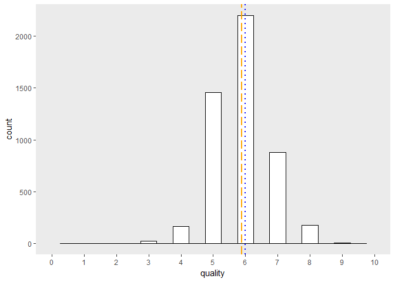

The distribution of quality is approximately normal. With a median of 6 and mean of 5.878, we can see the center of the data is slightly skewed toward the higher values. I would say the data exhibits a very slight left skew.

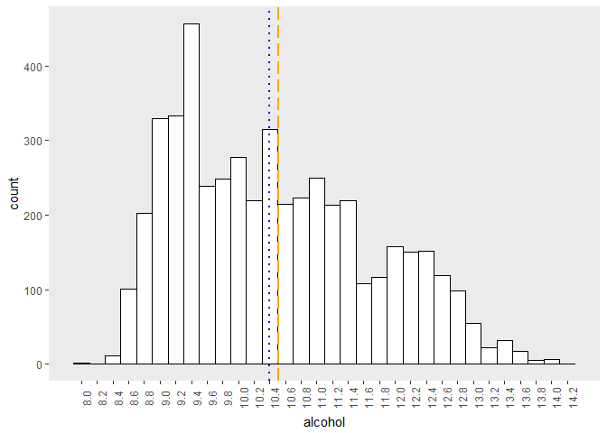

This is interesting because the data for alcohol is not normally distributed. The data is right skewed with the mean and median values at 10.51 and 10.4 respectively. However, the largest bin is 9.4 percent alcohol by volume.

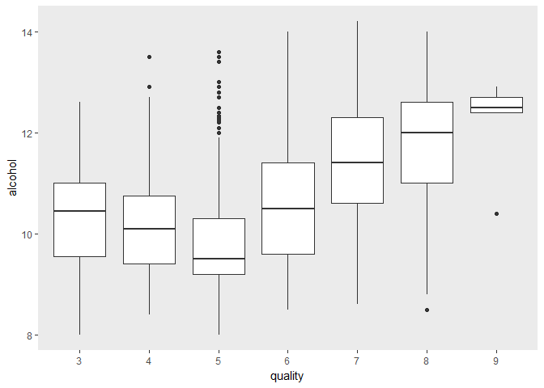

It appears that in most, but not all cases, the alcohol content is more positively correlated with wine quality. The Pearson correlation coefficient is 0.4355747.

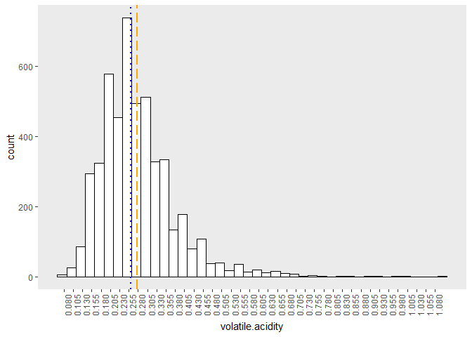

The volatile acidity can, in high amounts, impart vinegar-like taste. The data for this feature is significantly right skewed. I was hoping to use this feature to correlate with quality, but the few samples of high values might make that a futile endeavor.

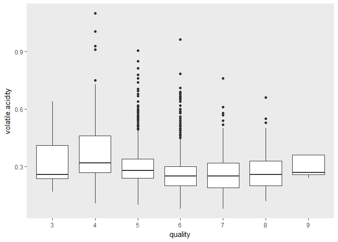

The variability of volatile acidity across quality is not great and the correlation seems very weak at best. At least initially, this appears to be a dead end from an analytical perspective.

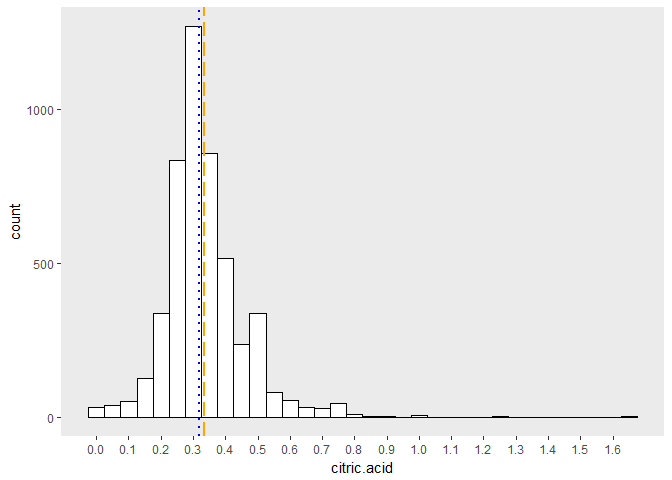

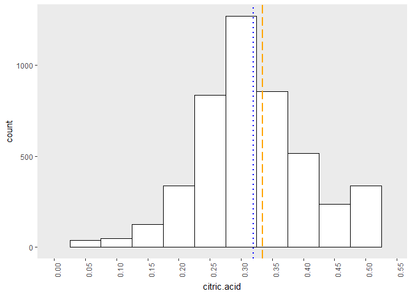

After zooming in to exclude outliers, the distribution is relatively normal. I might be able to combine this feature with another, or others, and glean some significant insights from it.

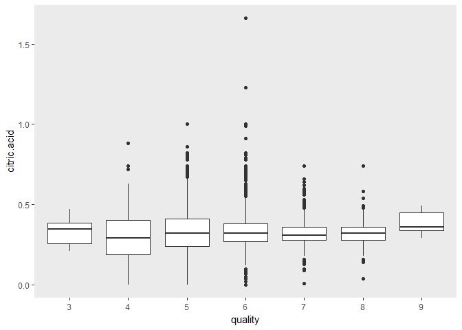

Citric acid adds a freshness or light flavor to wine. The data for this feature is right skewed. Similar to volatile acidity, I was hoping to use this feature to correlate with quality, but the few samples of high values might discount that effort as well.

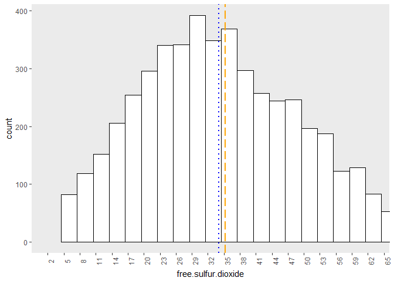

After zooming in to exclude outliers, the distribution of free sulfur dioxide is normal. This is a feature I may be able to work with during later analysis.

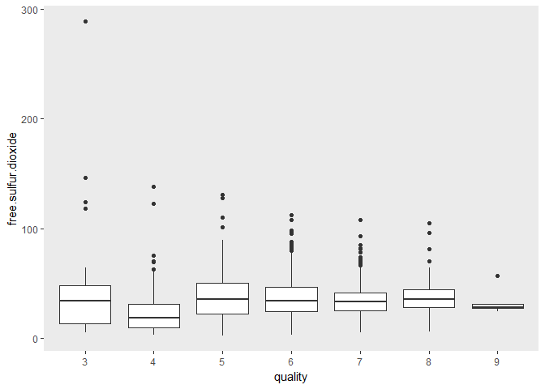

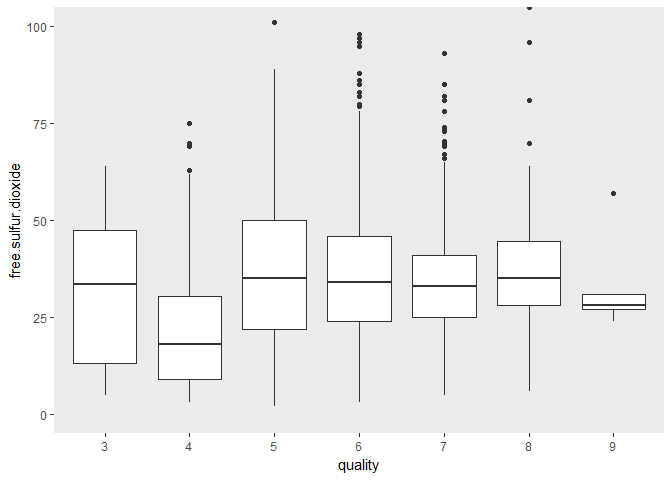

The free.sulfur.dioxide by quality, however, is not very significant in terms of correlation. I will need to use this feature in conjunction with another.

Let’s create a new feature as the percentage of free sulfur dioxide. This is calculated by dividing `free.sulfur.dioxide` by `total.sulfur.dioxide`. The new feature will be called so2.percent.

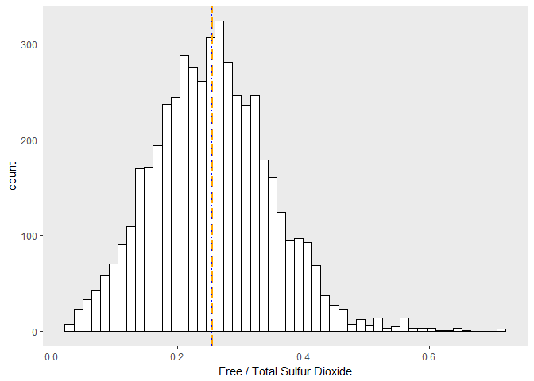

I think this percentage feature can allow me greater insights into the quality of white wines. SO2 is required to prevent oxidation, however, a balance must be found to prevent a strong sulfuric smell in the nose or the taste.

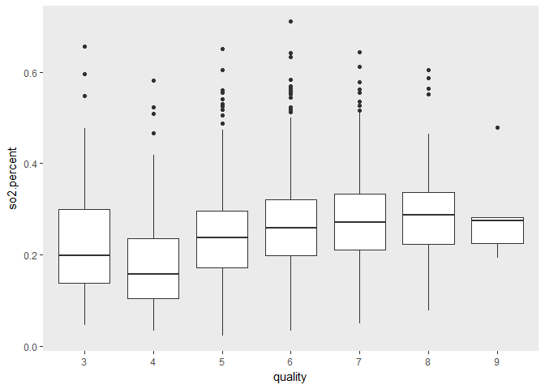

# Univariate Analysis

#### What is the structure of your dataset?

The data is now structured with 12 continuous features and 1 discrete, categorical output feature. With nearly 5000 observations, I may be able to glean more detailed insights or create more granular plots as compared to the red wines dataset of 1600 observations.

#### What is/are the main feature(s) of interest in your dataset?

The primary feature I am interested in is the output variable, quality. If the wine does not taste good, no one will drink it or even give much thought to its characteristics influencing that quality.

#### What other features in the dataset do you think will help support your investigation into your feature(s) of interest?

The other features I am interested in pertain to specific influences of taste. These are residual sugar and various measures of acidity.

#### Did you create any new variables from existing variables in the dataset?

I created a single new variable as free sulfur dioxide divided by the total sulfur dioxide. This proporation is normally distributed and may allow a better spread of the data while trying to extract meaningful insights.

#### Of the features you investigated, were there any unusual distributions? Did you perform any operations on the data to tidy, adjust, or change the form of the data? If so, why did you do this?

While I did not have to clean the data or make it tidy, I did observe unusual distributions of a handful of features. The unusual distribution could lead to some interesting insights, or perhaps lead me to a dead end.

# Bivariate Plots Section

```
##                      fixed.acidity volatile.acidity citric.acid
## fixed.acidity                1.000           -0.023       0.289
## volatile.acidity            -0.023            1.000      -0.149
## citric.acid                  0.289           -0.149       1.000
## residual.sugar               0.089            0.064       0.094
## chlorides                    0.023            0.071       0.114
## free.sulfur.dioxide         -0.049           -0.097       0.094
## total.sulfur.dioxide         0.091            0.089       0.121
## density                      0.265            0.027       0.150
## pH                          -0.426           -0.032      -0.164
## sulphates                   -0.017           -0.036       0.062
## alcohol                     -0.121            0.068      -0.076
## quality                     -0.114           -0.195      -0.009
## so2.percent                 -0.139           -0.196       0.016
##                      residual.sugar chlorides free.sulfur.dioxide
## fixed.acidity                 0.089     0.023              -0.049
## volatile.acidity              0.064     0.071              -0.097
## citric.acid                   0.094     0.114               0.094
## residual.sugar                1.000     0.089               0.299
## chlorides                     0.089     1.000               0.101
## free.sulfur.dioxide           0.299     0.101               1.000
## total.sulfur.dioxide          0.401     0.199               0.616
## density                       0.839     0.257               0.294
## pH                           -0.194    -0.090              -0.001
## sulphates                    -0.027     0.017               0.059
## alcohol                      -0.451    -0.360              -0.250
## quality                      -0.098    -0.210               0.008
## so2.percent                   0.051    -0.033               0.739
##                      total.sulfur.dioxide density     pH sulphates alcohol
## fixed.acidity                       0.091   0.265 -0.426    -0.017  -0.121
## volatile.acidity                    0.089   0.027 -0.032    -0.036   0.068
## citric.acid                         0.121   0.150 -0.164     0.062  -0.076
## residual.sugar                      0.401   0.839 -0.194    -0.027  -0.451
## chlorides                           0.199   0.257 -0.090     0.017  -0.360
## free.sulfur.dioxide                 0.616   0.294 -0.001     0.059  -0.250
## total.sulfur.dioxide                1.000   0.530  0.002     0.135  -0.449
## density                             0.530   1.000 -0.094     0.074  -0.780
## pH                                  0.002  -0.094  1.000     0.156   0.121
## sulphates                           0.135   0.074  0.156     1.000  -0.017
## alcohol                            -0.449  -0.780  0.121    -0.017   1.000
## quality                            -0.175  -0.307  0.099     0.054   0.436
## so2.percent                        -0.013  -0.066  0.001    -0.022   0.064
##                      quality so2.percent
## fixed.acidity         -0.114      -0.139
## volatile.acidity      -0.195      -0.196
## citric.acid           -0.009       0.016
## residual.sugar        -0.098       0.051
## chlorides             -0.210      -0.033
## free.sulfur.dioxide    0.008       0.739
## total.sulfur.dioxide  -0.175      -0.013
## density               -0.307      -0.066
## pH                     0.099       0.001
## sulphates              0.054      -0.022
## alcohol                0.436       0.064
## quality                1.000       0.197
## so2.percent            0.197       1.000
```

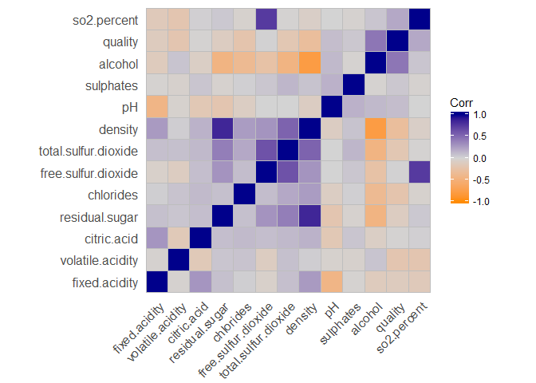

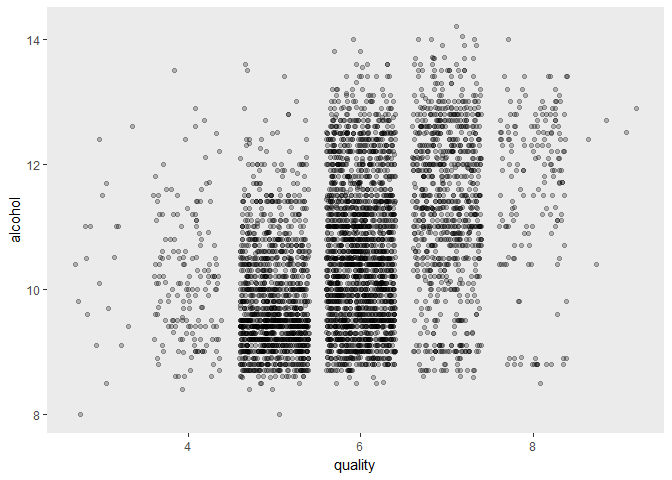

Although faint, there may a positive correlation between quality and alcohol content. The correlation coefficient of these two features is 0.4355747.

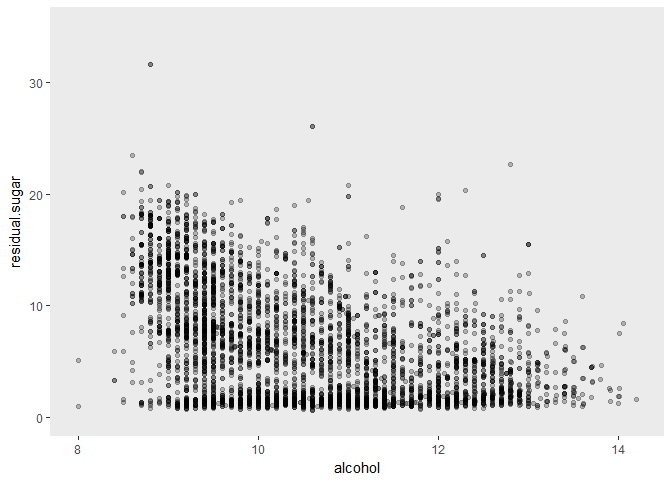

This plot suggests a weak to moderate negative correlation between alcohol and residual sugar. Higher residual sugar levels more frequently correspond to lower alcohol levels. This surprises me to certain degree because other types of strong alcohols try to make their beverage more palatable and to mask the strength of the alcohol. This, however, suggests many of the strong wines have lower levels of residual sugar.

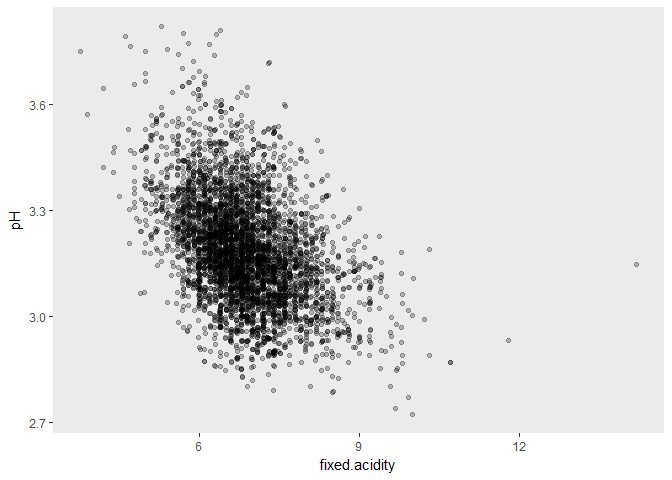

pH and fixed.acidity shows a moderate negative correlation as I expected. This is due to acids being represented by lower values on the pH scale.

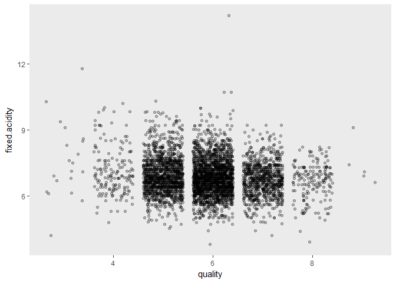

I was hopeful the fixed acidity level might be well described by quality; however, the correlation appears to be weakly negative to not correlated.

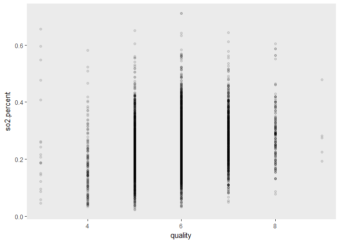

The percentage of free sulfur dioxide compared to the total, did not end up as descriptive as I anticipated it could be, nor predictive in terms of one being described by the other.

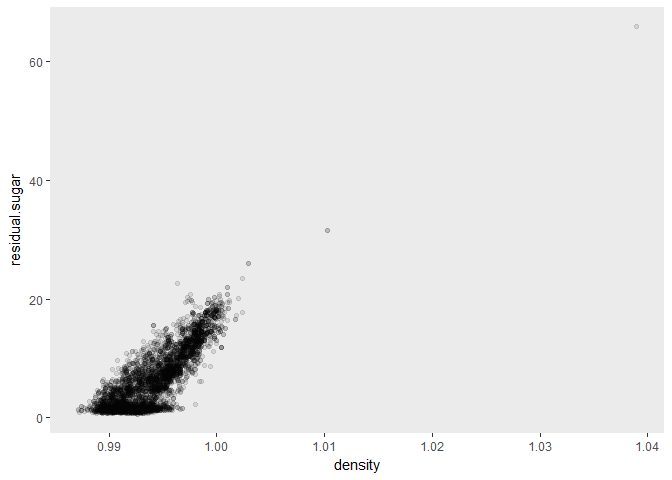

Even without zooming in to confirm at a smaller scale, I can see a strongly positive correlation between density and residual sugars. This is expected because sugar is typically heavier and more dense than the other chemicals composing a beverage or other liquid solution.

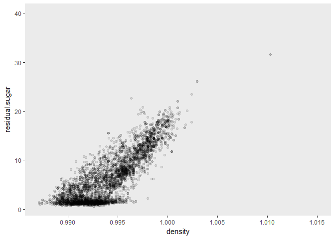

Zoomed in, the previous plot trendline is more easily observed. There is a correlation between density and residual.sugar

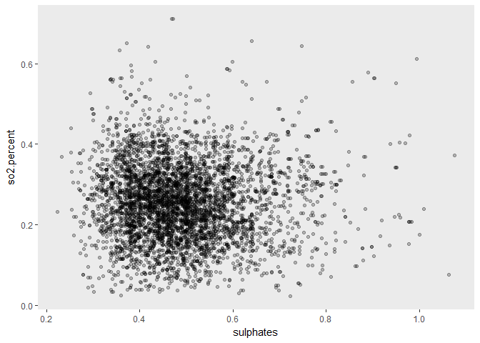

I was genuinely surprised there is effectively no correlation between sulphates and so2.percent. I would expect one feature to influence the other, yet this plot suggests that is not the case.